# Lecture 07: Multicollinearity

Module on Linear Regression

Author

Fisher, Compton and Hughes

# Goals for Today

- Review the complete data analysis of a regression problem
- Discuss the concept of repeated information in a model
- Formally define and discuss Multicollinearity
  - How to detect it
  - What it does to a model
  - Steps to remedy (if necessary)

# Conceptual Topic: Information in Regression

Ultimately, we will discuss the phenomenon of **Multicollinearity**. What it is, and how it effects a regression analysis. It is often misunderstood. We develop the idea today while looking at two different datasets.

We begin by considering one of our working examples, the small colleges in Ohio.

## EX: Small Colleges in Ohio

A college admissions board wished to study the relationship between 6 year graduation rates and several other variables. A random sample of 52 small colleges (enrollments between 1,000 and 4,999) from the state of Ohio were sampled and the following variables were collected:

- The 6 year graduation rate – percentage of students who graduate within 6 years of enrolling at the university.
- The average cost – The average cost of attendance for in-state students (record in dollars).
- Student-faculty-ratio – The number of full-time undergraduate students divided by the number of full-time faculty.
- Private or Public school – An indicator variable determining if the university is a private institution (recorded as a one) or a public institution (recorded as a zero).

The data appear in the text file `ohio_small_colleges.csv` on Dr Fisher’s website.

**Data source**: *The Education Trust* (2022) “College results”. https://collegeresults.org/

### Identification of Problem

Note the data is *observational*, and the goal is to “study the relationship between 6 year graduation rate and several other variables.” So this is NOT a designed experiment, and several of these “other” variables are numeric predictor variables - Multiple Regression will be the tool for this analysis.

### Data Input and Management

First we input the data and do some light data handling.

```r
oh_colleges <- read_csv("https://tjfisher19.github.io/data/ohio_small_colleges.csv",
                     show_col_types = FALSE)

oh_colleges <- oh_colleges |>
  mutate(Private_College_fct = factor(Private_College,
                                      levels=c(0,1),
                                      labels=c("Public", "Private")))
```

### Exploratory Data Analysis

In most regression settings, an exploratory data analysis can be achieved through the analysis of a matrix of scatterplots. We can use the `ggpairs()` function from the `GGally` package.

```r
ggpairs(oh_colleges, columns=c(3,4,6,2) ) +
  theme_bw()
```

The resulting plot looks like:

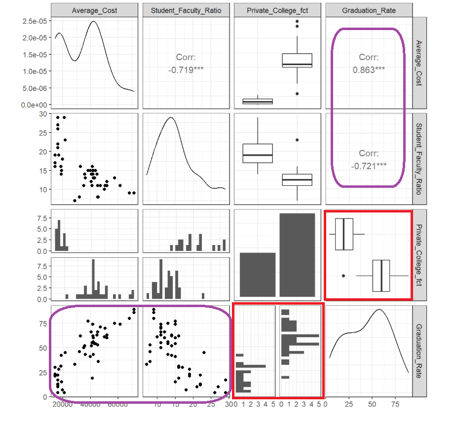

From the pairs plot we can make the following conclusions

- Average cost has strong positive correlation (0.863) with Graduation rates (highlighted in purple).
  - The relation appears fairly linear in the scatterplot.
- Student-to-faculty ratio has a fairly strong negative correlation (-0.721) with Graduation rates (highlighted in purple).
  - The relation appears fairly linear in the scatterplot.
- The indicator variable, or factor variable, determining if the college is “Public” or “Private” appears to be associated with Graduation Rates (highlighted in red).
  - The Box-Whiskers plot show clear separation.
  - The faceted histograms show one distribution is shifted away from the other.

From this EDA, it appears the predictor variables (Average Cost, Student-to-faculty ratio and public/private college) are likely predictive of Graduation Rate.

### Multiple Regression Model

We fit a multiple regression model.

```r
oh_college_fit <- lm(Graduation_Rate ~ Average_Cost + Student_Faculty_Ratio + Private_College,
                  data=oh_colleges)
```

We then assess the underlying assumptions of that model (recall the acronym L.I.N.E.).

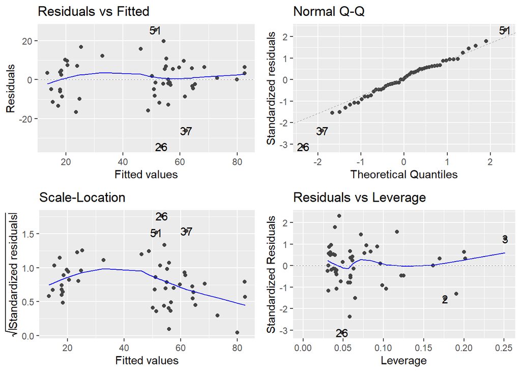

```r
autoplot(oh_college_fit)
```

- **Independence** - we get independence by considering the context of the data and how it was sampled.
  - Generally speaking, a student can only be registered at one university and can only graduate from one university.
  - The dataset consist of a random sample of small colleges in Ohio.
  - Between these two ideas, we can be reasonably assured the underlying data is independent.
- **Linearity** - we assume the relationship between the predictor variables and the response is linear. This is assessed through the EDA and the Residuals vs Fitted plots.
  - In the EDA, both Average Cost and Student-to-faculty ratio appear to have a reasonably linear relationship with Graduation Rate.
  - The other variable is an indicator or factor variable. It just shifts any modeled relationship, so it is not a concern for linearity.
  - In the Residuals vs Fitted plot, we look at the smoother trend (the blue line). There, we see it fluctuating around the $x$-axis is a non-systematic way (no clear trend or curvature).
  - Collectively, this allows us to be reasonably assured the relationship is linear.
- **Constant Variance** - we assume the underlying noise terms have constant variance. This is assessed through the Residuals vs Fitted plot and Scale-Location plot.
  - In the Residuals vs Fitted plot we look for systematic patterns in the vertical spread of the plotted points. Here, we see nothing clear (like the *fanning* we have seen in other examples).
  - In the Scale-Location plot we look for a clear trend in the plotted smoother (blue line). Here, the trend goes up a little and then back down. But nothing overly concerning (like a constant clear upward trend).
  - From these two figures, we can be reasonably assured the underlying noise terms have constant variance.
- **Normality** - To assess Normality, we assess the Normal Q-Q plot. The plotted plots should reasonably follow a 45-degree line.
  - Here, all points are reasonably close to the 45-degree line, except for observation 26.
  - In a previous lecture we explored that point and did not find any errors or anything wrong with the data, it is just an outlying observation (it happens!).
  - Overall, the underlying residual terms appear to be Normally distribution.

So overall, our assumptions appear to be met!

### Regression Inference

Most of our decisions can be made using the output from the `summary()` function:

```r
summary(oh_college_fit)
```

```
Call:
lm(formula = Graduation_Rate ~ Average_Cost + Student_Faculty_Ratio +
    Private_College, data = oh_colleges)

Residuals:
    Min      1Q  Median      3Q     Max
-34.388  -5.320   0.527   6.528  25.580

Coefficients:
                        Estimate Std. Error t value Pr(>|t|)
(Intercept)           18.9218217 10.8803827   1.739   0.0884 .
Average_Cost           0.0008211  0.0001843   4.454 5.02e-05 ***
Student_Faculty_Ratio -0.6490195  0.4494458  -1.444   0.1552
Private_College       10.8632819  6.2775072   1.731   0.0900 .
---
Signif. codes:  0 '***' 0.001 '**' 0.01 '*' 0.05 '.' 0.1 ' ' 1

Residual standard error: 11.32 on 48 degrees of freedom
Multiple R-squared:  0.7791,    Adjusted R-squared:  0.7653
F-statistic: 56.44 on 3 and 48 DF,  p-value: 9.04e-16
```

**Does the model predict Graduation Rates?**

With an $F$-statistic of 56.44 on 3 and 48 degrees of freedom ($p$-value $\approx 10^{-16}$), we have clear evidence that the model involving Average Cost, Student-to-faculty ratio and an indicator if it is a public or private college, predicts the 6-year Graduation Rate.

**How well does the model predict, or explain, Graduation Rates?**

The model explains approximately 77% of the variability in Graduation Rates. On average, the model predicts Graduation Rates with an error of about 11.32 percent.

**What variables appear important?**

Here, things get interesting.

- When a model already includes Student-to-faculty ratio and the indicator of whether it is a public or private college, the addition of Average cost is a significant predictor for Graduation Rate ($t$-stat of 4.454, $p$-value $\approx 10^{-5}$).
- When a model already includes Average Cost and the indicator of whether it is a public or private college, the addition of Student-to-faculty ratio is NOT a significant predictor for Graduation Rate ($t$-stat of -1.444, $p$-value $=0.1552$).
- When a model already includes Average Cost and Student-to-faculty ratio, the addition of the indicator of whether it is a public or private college is NOT a significant predictor for Graduation Rate ($t$-stat of 1.731, $p$-value $=0.0900$).

We have two predictor variables that appear to be not significant when assessed marginally. In a previous lecture, we tested their joint effect using a reduced $F$-test.

```r
oh_college_cost_slr <- lm(Graduation_Rate ~ Average_Cost,
                          data=oh_colleges)
anova(oh_college_cost_slr, oh_college_fit)
```

```
Analysis of Variance Table

Model 1: Graduation_Rate ~ Average_Cost
Model 2: Graduation_Rate ~ Average_Cost + Student_Faculty_Ratio + Private_College
  Res.Df    RSS Df Sum of Sq      F  Pr(>F)
1     50 7119.9
2     48 6155.3  2    964.61 3.7611 0.03038 *
---
Signif. codes:  0 '***' 0.001 '**' 0.01 '*' 0.05 '.' 0.1 ' ' 1
```

With an $F$-statistic of 3.7611 on 2 and 48 degrees of freedom ($p$-value $= 0.03038$) we have evidence that the addition of Student-to-faculty ratio and the indicator variable of a public or private college, improves the prediction of a model only including Average Cost.

### Disccusion on Contradiction?

On a quick observation, we may see what looks to be a *contradiction* in the above analysis.

- By the EDA, Student-to-faculty ratio and the Private/Public college factor variable appear to predict Graduation Rates.
- The marginal $t$-test in the regression output suggest they are not significant predictors.
- The reduced $F$-test suggest the inclusion of both variables improves on a model that only included average cost.

So what is going on… For that, let’s step back and think about everything abstractly and contextually.

When we fit a regression model (or ANOVA for that matter), we are essentially checking to see if there is **information in the predictor variables** that help **explain** the variability in **the response variable.**

Well, let’s consider some context regarding the `Average_Cost` predictor variable in this example.

`Average_Cost` – the average cost to attend the college. What contextual factors would potentially influence cost? (a non-exclusive list is provided)

- How much the state of Ohio subsidizes the college?
  - Private schools receive little-to-no state funding.
  - Public schools receive state funding.
- Tuition - the tuition of a college is a primary cost for a student.
  - The state of Ohio dictates tuition rates for public schools and helps control cost through funding.
  - For private schools, the tuition rates are normally higher unless they have a very large endowment.
- Endowment - essentially this is how much a college has in their savings account.
  - A large endowment generally means they do not need to charge as much for tuition.
- Operational cost - A university/college essentially spends money on two main items: employees and maintenance of facilities.
  - A large subgroup of the employees at a University or College are the faculty.

Note that several of the items above include information about Private vs Public schools, and the number of faculty working at the university. It shouldn’t be too difficult to realize that our three predictor variables include some overlapping (or repeated) information!

We can see this visually when exploring the pairs plot.

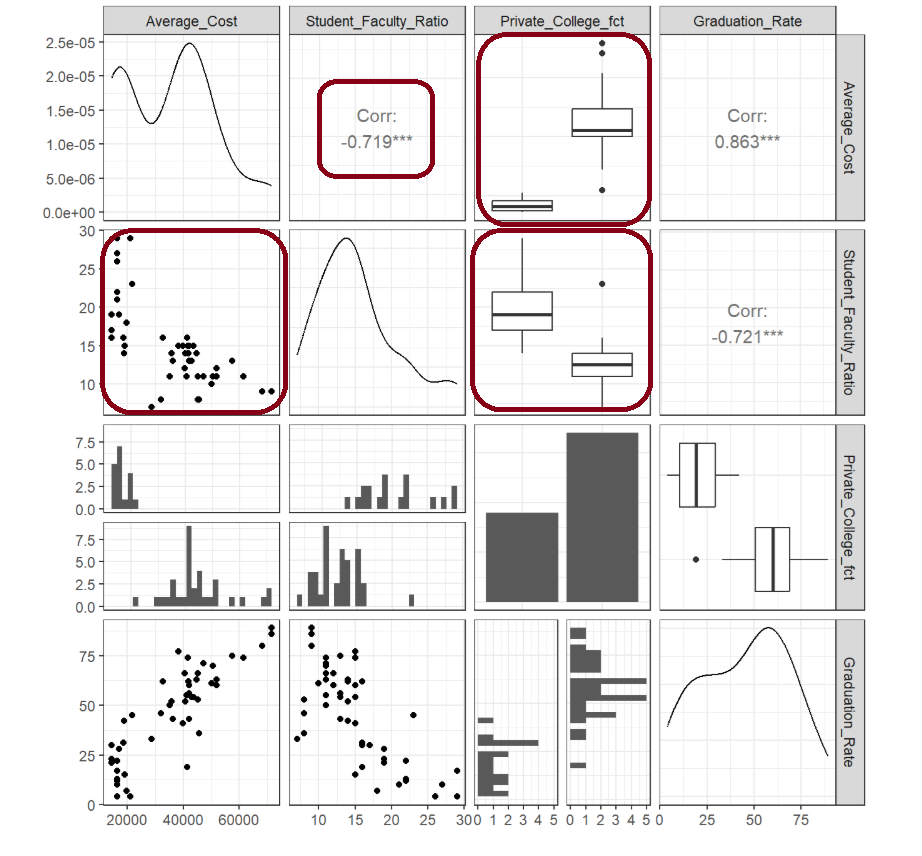

- `Average_Cost` and `Student_Faculty_Ratio` are negatively correlated (-0.719) (highlighted in red).
- `Average_Cost` and the Public or Private school indicator variable surely seem associated based on the Box-plots showing nearly perfect separation (highlighted in red).
- `Student_Faculty_Ratio` and the Public or Private school indicator also seem associated based on the separated in the Box-whiskers plots (highlighted in red).

So in short, all three predictor variables are supplying **some of the same information** to predict Graduation Rates.

This concept of repeated or overlapping information leads to a statistical phenomenon that can happen when modeling known as **Multicollinearity**.

# Multicollinearity

Multicollinearity is a condition when there are interrelationships (correlations) of substantial strength **among the predictor variables** in a model. This can create issues when interpreting the impact or significance of individual predictor variables on the response variable.

Since interpreting predictor variables is one of the main uses of regression analysis, it can be a serious issue impacting the practical usefulness of a model.

Before we address some strategies on handling multicollinearity, first note the following:

- Multicollinearity has **nothing to do with the response variable** $Y$: it is solely an issue about the predictor variables.
- Multicollinearity does **not** affect “whole-model” assessments like the overall $F$-test, adjusted $R^2$, residual standard errors, or quality of prediction on the response.
- However, **serious** cases of **Multicollinearity** can make **interpretation** and **contribution** of individual predictors **difficult**.
  - That is, the estimated *coefficients* may not make contextual sense; *e.g.,* a negative $\beta$-coefficient when the correlation with the response was positive.
  - Conflicting $t$-test results when you fit different models or all $t$-test appear insignificant; thus you cannot meaningful determine which variables appear important.

## Checking for Multicollinearity

There are a few clues you can look for to see if you have a multicollinearity problem. They are:

1. **Seeing strong pairwise correlations between predictors in your EDA scatterplot matrix.** It should be noted that multicollinearity can arise from more complex correlations than simple pairwise comparisons, so this check is not the best overall check for multicollinearity.
2. **Model “Weirdness”.** If you see output such as a significant whole model $F$-test result, but *none* of the individual model term tests are significant, you might have strong multicollinearity. Another clue is $\beta$-coefficient estimates that are different in direction (the $\pm$ sign) than what common sense or the EDA would predict.
3. **VIF**. Variance Inflation Factors (VIFs) are the best check for multicollinearity. There is a VIF for each predictor, and it is obtained by seeing how well you can predict a given predictor variable from the *other* predictors in the model.

### Variance Inflation Factors

The Variance Inflation Factor of a predictor variable is essentially a measure how correlated that variable is with all the other predictor variables (collectively). It can be calculated by fitting a linear regression with one predictor variable as the response, and all other (predictor) variables as the predictors. In practice, we will never fit those models manually. VIFs are available in R using the `car` package.

```r
library(car)
vif(oh_college_fit)
```

```
         Average_Cost Student_Faculty_Ratio       Private_College
             3.561726              2.316818              3.616723
```

When a predictor variable is entirely independent of the other variables, its VIF value should be one. At larger values (VIF $>10$), this indicates a particular predictor variable is likely providing the same information as the other variables. A VIF $>5$ can be an indication that multicollinearity could be causing some issues.

Here, we note that all three VIFs are greater than 1 but none are substantially high, so overall there is nothing too concerning with this model. We can interpret the effects of each variable and the $t$-test results with some confidence.

### Re-evaluation the so-called contradiction?

So why do the $t$-test appear to contradict some of our other findings with this data? It is not a contradiction so much as a poor interpretation of the marginal $t$-test. Remember, those $t$-test determine if a variable is significant when the other variables are included. So although not obvious, the results here are actually fairly consistent.

- The model predicts graduation rates (overall $F$-test).
- Average cost helps improve prediction when including a model with student-to-faculty ratio and private/public college ($t$-test on `Average_Cost`).
- Including student-to-faculty ratio and private/public college improves on a model compared to just using average cost (reduced model $F$-test).
- But…
  - Adding Student-to-faculty ratio to a model with Average Cost AND Public/Private does not help prediction ($t$-test on `Student_Faculty_Ratio`); and
  - Adding Public/Private to a model with Average Cost AND Student-to-faculty ratio does not help prediction ($t$-test on `Private_College`).

**Serious cases of multicollinearity can create some really strange results, as we’ll see in the next example.**

## Ex: Car seat position

Drivers of automobiles often adjust the seat position for their own comfort. Car designers find it helpful to know where different drivers will position the seat depending on their size and age. Researchers at the Human Motion Simulation Laboratory at the University of Michigan collected data on 38 drivers recording measurements on their size and the location of the seat when driving a vehicle.

Here are variables in the data set:

- `Age` of the driver (years)
- `Weight` of the driver (lbs)
- `HtShoes` record the driver’s height when in shoes (cm)
- `Ht` records the driver’s height in bare feet (cm)
- `Seated` records the height of the driver when seats (cm)
- `Arm` is the length of the forearm (cm)
- `Thigh` is the length of the driver’s thigh (cm)
- `Leg` is the length of the lower leg (cm)
- `hipcenter`: Horizontal distance of the midpoint of the hips from a fixed location in the car (cm)

```r
seat_position <- read_csv("https://tjfisher19.github.io/data/seatpositions.csv",
                          show_col_types = FALSE)
```

We will build a model to predict `hipcenter`.

### Full Main Effects Model

We start with a full main effects models, expecting to see some goofy behavior since `Ht` and `HtShoes` are essentially the same variable! We exclude an EDA plot for now (will revisit later).

**CODING NOTE**: We use some special code to fit this model: `hipcenter ~ .`, this tells R to use the `hipcenter` variable as a the response variable and to use ALL the other variables in the dataset as predictors. Care must be taken to use this code – if identifier variables are included (Name of participant?) or factor variables are not handled correctly, or repeated, you will get STRANGE RESULTS.

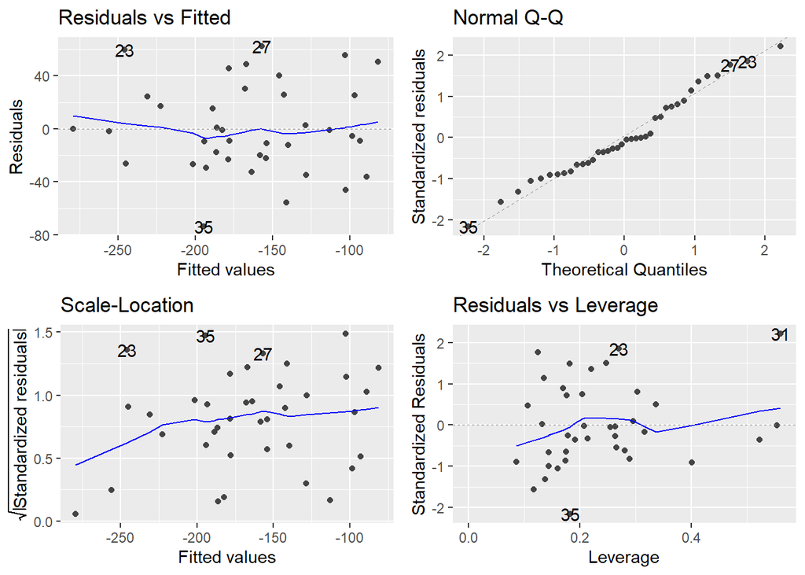

```r
seat_full_model <- lm(hipcenter ~ ., data=seat_position)
autoplot(seat_full_model)
```

Overall the residual plots look reasonable. There is nothing overly concerning with linearity, constant variance or normality. Let’s look at the model output.

```r
summary(seat_full_model)
```

```
Call:
lm(formula = hipcenter ~ ., data = seat_position)

Residuals:
    Min      1Q  Median      3Q     Max
-73.827 -22.833  -3.678  25.017  62.337

Coefficients:
             Estimate Std. Error t value Pr(>|t|)
(Intercept) 436.43213  166.57162   2.620   0.0138 *
Age           0.77572    0.57033   1.360   0.1843
Weight        0.02631    0.33097   0.080   0.9372
HtShoes      -2.69241    9.75304  -0.276   0.7845
Ht            0.60134   10.12987   0.059   0.9531
Seated        0.53375    3.76189   0.142   0.8882
Arm          -1.32807    3.90020  -0.341   0.7359
Thigh        -1.14312    2.66002  -0.430   0.6706
Leg          -6.43905    4.71386  -1.366   0.1824
---
Signif. codes:  0 '***' 0.001 '**' 0.01 '*' 0.05 '.' 0.1 ' ' 1

Residual standard error: 37.72 on 29 degrees of freedom
Multiple R-squared:  0.6866,    Adjusted R-squared:  0.6001
F-statistic:  7.94 on 8 and 29 DF,  p-value: 1.306e-05
```

With an $F$-statistic of 7.94 on 8 and 29 degrees of freedom ($p$-value $\approx 10^{-5}$), we have evidence that the model predicts the `hipcenter` variable.

The model explains approximately 60% of the variability in the `hipcenter` variable based on the adjusted $R^2$ value.

Yet, none of the predictor variables are significant! What is going on… Let’s look at the VIF values for some insight.

```r
vif(seat_full_model)
```

```
       Age     Weight    HtShoes         Ht     Seated        Arm      Thigh
  1.997931   3.647030 307.429378 333.137832   8.951054   4.496368   2.762886
       Leg
  6.694291
```

We see several VIF values that are large. Specifically, the person’s height and their height in shoes (basically the same measure), have very elevated VIF values and are causing all sorts of craziness in the model.

## Strategies for dealing with Multicollinearity

There are a few simple things to try (and there are more sophisticated strategies too, but they are beyond the scope of this course). They are:

1. **Standardize all of your quantitative variables.** When you have non-linear predictor variables in the model (*e.g.*, a model includes both an $X$ and an $X^2$ as predictor variables), standardizing can sometimes reduce the impact of Multicollinearity. Basically, you re-express all the numeric variables in the model as *z-scores* by subtracting their mean and dividing by their standard deviation.
   - **Do not standardized any categorical or dummy variables!**
   - This does not always work, but it is worth a try.
   - One nice by-product of standardizing your variables is that the relative impact of the predictors can now be compared directly between themselves, because standardizing removes the effect of different units of measurement on different predictors.
2. **Remove a predictor (or predictors) that induce the Multicollinearity.** Pretty simple, but you should explore model options if doing this (Chapter 9 of the text covers this topic).

### Standardizing Predictors

Our model does not include any nonlinear predictor variables, so we do not expect standardizing to have much of an effect, but we include it below to demonstrate how to do it.

Here we show you standardizing the variables using `mutate()` with the `across` option (*mutates* all specified variables with the `scale` function) to see the result on the regression. We also recheck the VIFs:

First, a function that standardizes a vectors

```r
standardize_vector <- function(x) {
  (x - mean(x) )/sd(x)
}
```

Using a specialized version of `mutate()` (search in the help documentation about `across`), we standardize all variables except the response variable (hence, `!hipcenter`).

```r
std_seat_position <- seat_position |>
  mutate(across(!hipcenter, ~ standardize_vector(.) ) )
```

Now we can fit the model with this standardized data.

```r
std_seat_full_model <- lm(hipcenter ~ ., data=std_seat_position)
summary(std_seat_full_model)
```

```
Call:
lm(formula = hipcenter ~ ., data = std_seat_position)

Residuals:
    Min      1Q  Median      3Q     Max
-73.827 -22.833  -3.678  25.017  62.337

Coefficients:
             Estimate Std. Error t value Pr(>|t|)
(Intercept) -164.8849     6.1190 -26.946   <2e-16 ***
Age           11.9218     8.7653   1.360    0.184
Weight         0.9415    11.8425   0.080    0.937
HtShoes      -30.0157   108.7294  -0.276    0.784
Ht             6.7190   113.1843   0.059    0.953
Seated         2.6324    18.5529   0.142    0.888
Arm           -4.4775    13.1494  -0.341    0.736
Thigh         -4.4296    10.3076  -0.430    0.671
Leg          -21.9165    16.0445  -1.366    0.182
---
Signif. codes:  0 '***' 0.001 '**' 0.01 '*' 0.05 '.' 0.1 ' ' 1

Residual standard error: 37.72 on 29 degrees of freedom
Multiple R-squared:  0.6866,    Adjusted R-squared:  0.6001
F-statistic:  7.94 on 8 and 29 DF,  p-value: 1.306e-05
```

Standardizing didn’t help in this case (all $t$-test still suggest no particular variable is important). So we’ll try some variable deletion instead.

### Removing Predictors

Fit a regression model using all the predictors *except* `Ht` (we picked this variable because it is essentially a replicate variable with `HtShoes` and had the higher VIF value of the two). Find the VIFs, and check adjusted $R^2$ and the residual standard error.

```r
seat_reduced_model <- lm(hipcenter ~ . - Ht, data=seat_position)
summary(seat_reduced_model)
```

```
Call:
lm(formula = hipcenter ~ . - Ht, data = seat_position)

Residuals:
    Min      1Q  Median      3Q     Max
-74.107 -22.467  -4.207  25.106  62.225

Coefficients:
             Estimate Std. Error t value Pr(>|t|)
(Intercept) 436.84207  163.64104   2.670   0.0121 *
Age           0.76574    0.53590   1.429   0.1634
Weight        0.02897    0.32244   0.090   0.9290
HtShoes      -2.13409    2.53896  -0.841   0.4073
Seated        0.54959    3.68958   0.149   0.8826
Arm          -1.30087    3.80833  -0.342   0.7350
Thigh        -1.09039    2.46534  -0.442   0.6615
Leg          -6.40612    4.60272  -1.392   0.1742
---
Signif. codes:  0 '***' 0.001 '**' 0.01 '*' 0.05 '.' 0.1 ' ' 1

Residual standard error: 37.09 on 30 degrees of freedom
Multiple R-squared:  0.6865,    Adjusted R-squared:  0.6134
F-statistic: 9.385 on 7 and 30 DF,  p-value: 4.014e-06
```

The model significantly predicts the `hipcenter` variable ($F$-statistic 9.385 on 7 and 30 degrees of freedom, $p$-value $\approx 10^{-6}$). Notice the adjusted $R^2$ has increased a little but all the individual predictor variables do not appear significant based on the conditional $t$-tests.

```r
vif(seat_reduced_model)
```

```
      Age    Weight   HtShoes    Seated       Arm     Thigh       Leg
 1.824607  3.580351 21.550054  8.906032  4.434329  2.454805  6.601632
```

We still see high VIF values in several variables. You could continue to try removing other variables but it is not clear what variable(s) to remove.

In situations like this, we need to use more advanced techniques known as “Model Selection” - we will cover that in a few lectures from now.

### Another Reduced Model

To demonstrate that Multicollinearity can exist even with a small number of predictor variables, consider a model for `hipcenter` where only `Age`, `HtShoes` and `Leg` are predictor variables. First, let’s look at a pairs plot of these variables.

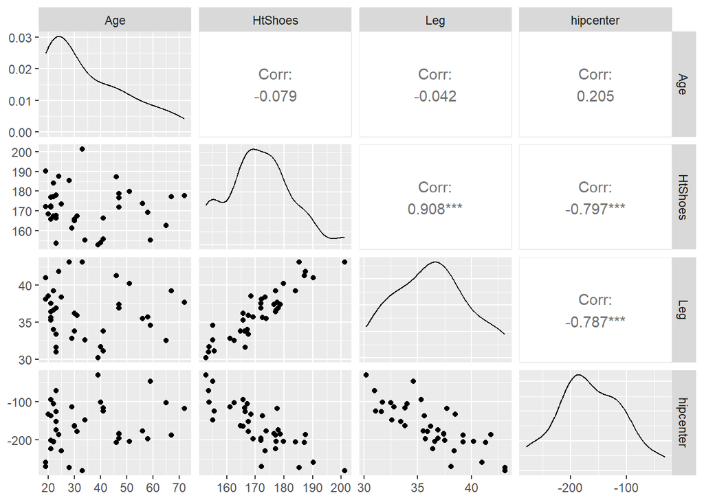

```r
ggpairs(seat_position, columns=c(1,3,8,9) )
```

- `Age` and `hipcenter` are weakly positively correlated.
- `HtShoes` and `hipcenter` are fairly strongly negatively correlated.
- `Leg` and `hipcenter` are fairly strongly negatively correlated.

We also note that `HtShoes` and `Leg` are strongly positively correlated.

Let’s proceed to fitting the model

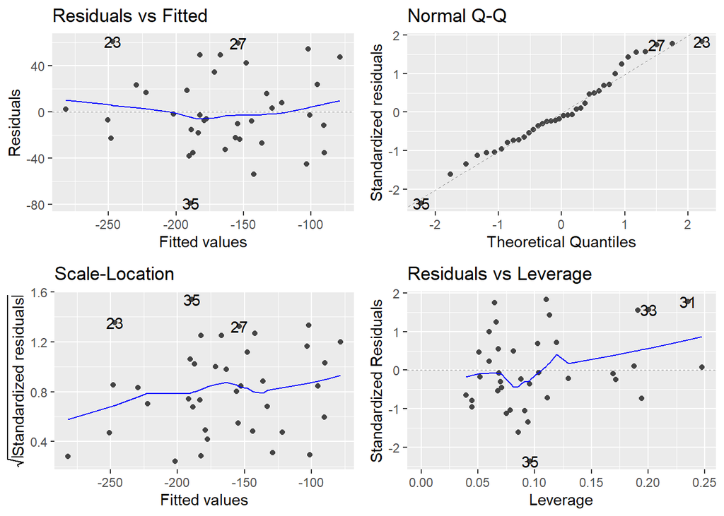

```r
seat_fit <- lm(hipcenter ~ Age + HtShoes + Leg, data=seat_position)
autoplot(seat_fit)
```

The residual plots look reasonable. So let’s look at the model output.

```r
summary(seat_fit)
```

```
Call:
lm(formula = hipcenter ~ Age + HtShoes + Leg, data = seat_position)

Residuals:
    Min      1Q  Median      3Q     Max
-79.269 -22.770  -4.342  21.853  60.907

Coefficients:
            Estimate Std. Error t value Pr(>|t|)
(Intercept) 456.2137   102.8078   4.438 9.09e-05 ***
Age           0.5998     0.3779   1.587   0.1217
HtShoes      -2.3023     1.2452  -1.849   0.0732 .
Leg          -6.8297     4.0693  -1.678   0.1024
---
Signif. codes:  0 '***' 0.001 '**' 0.01 '*' 0.05 '.' 0.1 ' ' 1

Residual standard error: 35.13 on 34 degrees of freedom
Multiple R-squared:  0.6813,    Adjusted R-squared:  0.6531
F-statistic: 24.22 on 3 and 34 DF,  p-value: 1.437e-08
```

The model significantly predicts `hipcenter` ($F$-stat of 24.22 on 3 and 34 degrees of freedom, $p$-value $\approx 10^{-8}$). Note the $R^2$ for this model and the original full fit model are similar, but the adjusted $R^2$ is higher here. But… all three predictor variables still do not appear significant.

```r
vif(seat_fit)
```

```
     Age  HtShoes      Leg
1.011467 5.777752 5.751729
```

Here, the VIF values are only slightly above 5 so not too concerning, but we still have some difficulty with measuring the contribution of each of the three variables. This is similar the Ohio Small Colleges example where two variables appeared important in the EDA but were not significant in the full model.

## Conclusions

**Remember:** Multicollinearity is *only* an issue when you are trying to **interpret** the magnitude and/or significance of **individual predictors** on the response. It does **NOT effect a model’s overall ability** to predict the response.

In future lectures we will discuss the topic of “Model Selection,” which is a series of rules & criteria, along with different methods to help determine useful and interpretable models.